# Efficient Animal Models in Stan

Joel Pick

2021-06-07

Two predominant programs are used for running animal models - `ASReml` and `MCMCglmm`. `ASReml` is frequentist, so runs fast and is pretty flexible. The downsides are that non-Gaussian models don't run so well, it isn't free and not many institutions have licenses. The Bayesian equivalent is `MCMCglmm`, which uses a very similar syntax to `ASReml` (until `ASReml-4`!). It runs non-Gaussian models well, is flexible and is free! The downside is that complex models take a while to run, as it uses MCMC chains. Both programs are formula based, so the user interacts with the program through a formula it specifies. Intrinsically this limits the user to the range of models that have been written into the program.

Probabilistic programming language, such as `Stan` (and `BUGS` and `JAGS`), allow you to write the code underlying a model yourself, making them extremely flexible. `Stan` uses Hamiltonian Monte Carlo instead of Gibbs Sampling (like `MCMCglmm`). This means that it is (in theory) also much faster than `MCMCglmm`. However, the process of writing and optimising itself can be time consuming, and requires a good understanding of how `Stan` works. Despite being slower to run, `MCMCglmm` might therefore be preferable in many situation as although it might run slower, it takes much less time to get the model up and running. In some situations, however, the required model structure might not be available in MCMCglmm.

There are `R` packages such as `brms`, which act as wrappers to `Stan`, allowing you to specify models using common model syntax in `R`, making many complex models much more accessible. `brms` is very flexible and alongside many other things `brms` can run animal models. To do this `brms` uses the relationship matrix derived from a pedigree to estimate additive genetic effects. However, `Stan` doesn't deal well with sparse matrices, as relationship matrices typically are.

Luckily, there is another way of building an animal model in `Stan` which is more efficient, through modelling the pedigree as a Directed Acyclic Graph (DAG).

# 1 Comparison of Methods

Before going into to detail of how to specify these models in `Stan`, I'm going to compare `MCMCglmm`, `brms` and my `Stan` code to demonstrate the potential gain in efficiency.

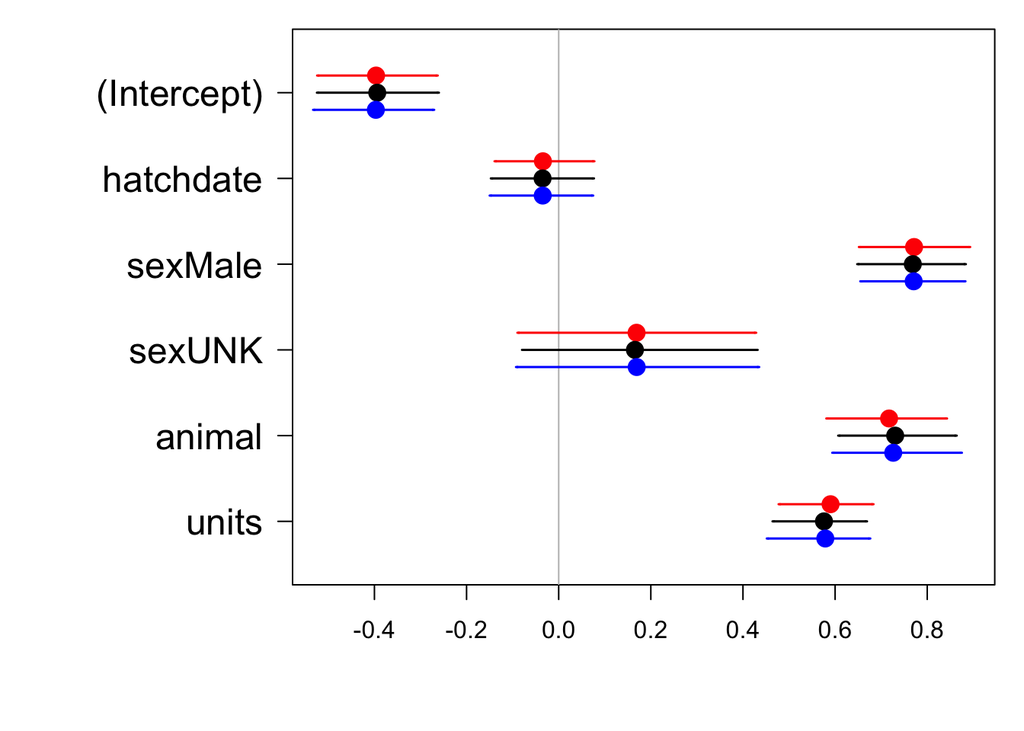

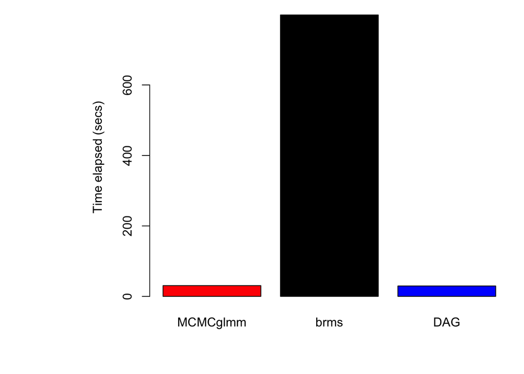

Effective sample size

|  | (Intercept) | hatchdate | sexMale | sexUNK | animal | units |
| --- | --- | --- | --- | --- | --- | --- |
| MCMCglmm | 2367.446 | 2000.000 | 2000.000 | 2249.912 | 356.12527 | 346.03212 |
| brms | 1492.631 | 1298.433 | 1993.874 | 2000.000 | 82.39743 | 71.42376 |
| DAG | 2077.790 | 2468.347 | 3659.171 | 3013.525 | 757.45630 | 805.64585 |

Second per effective sample

|  | (Intercept) | hatchdate | sexMale | sexUNK | animal | units |
| --- | --- | --- | --- | --- | --- | --- |
| MCMCglmm | 0.0129008 | 0.0152710 | 0.0152710 | 0.0135748 | 0.0857620 | 0.0882635 |
| brms | 0.5350725 | 0.6150999 | 0.4005599 | 0.3993330 | 9.6928504 | 11.1820775 |
| DAG | 0.0142238 | 0.0119732 | 0.0080767 | 0.0098071 | 0.0390174 | 0.0366836 |

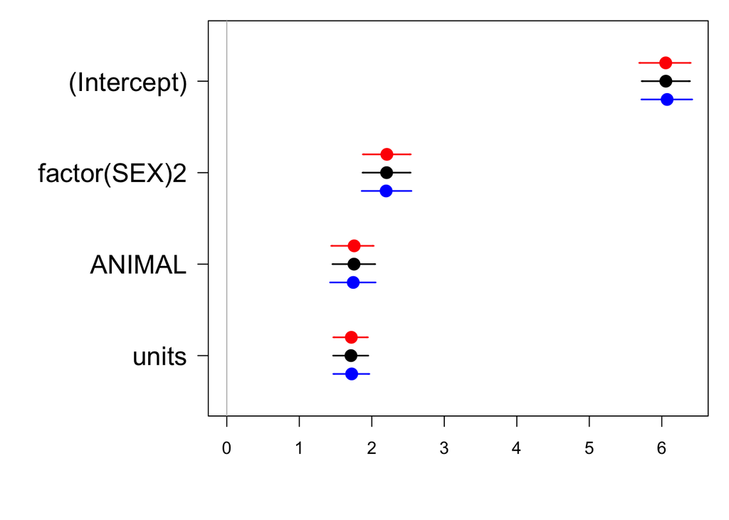

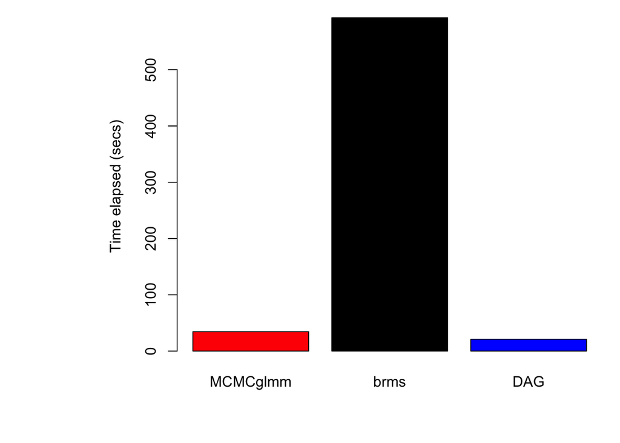

Effective sample size

|  | (Intercept) | factor(SEX)2 | ANIMAL | units |
| --- | --- | --- | --- | --- |
| MCMCglmm | 2000.0000 | 2000.000 | 477.9722 | 501.1793 |
| brms | 886.6437 | 1452.611 | 100.0559 | 101.8577 |
| DAG | 345.9372 | 1108.351 | 258.6087 | 241.3438 |

Second per effective sample

|  | (Intercept) | factor(SEX)2 | ANIMAL | units |
| --- | --- | --- | --- | --- |
| MCMCglmm | 0.0172250 | 0.0172250 | 0.0720753 | 0.0687379 |
| brms | 0.6681184 | 0.4078057 | 5.9205180 | 5.8157889 |
| DAG | 0.0606960 | 0.0189444 | 0.0811922 | 0.0870004 |